# Project: Investigate a Dataset - Gapminder World

### Research Question 25 (What is the distribution of Emplyment Rate for Girls 15+ between 1991 and 2019?)

```python
df_erg.head()
```

| country | continent | 1991 | 1992 | 1993 | 1994 | 1995 | 1996 | 1997 | 1998 | 1999 | ... | 2010 | 2011 | 2012 | 2013 | 2014 | 2015 | 2016 | 2017 | 2018 | 2019 |
| --- | --- | --- | --- | --- | --- | --- | --- | --- | --- | --- | --- | --- | --- | --- | --- | --- | --- | --- | --- | --- | --- |
| Afghanistan | Asia | 13.2 | 13.2 | 13.1 | 13.1 | 13.1 | 13.0 | 12.8 | 12.8 | 12.7 | ... | 12.9 | 13.2 | 13.5 | 14.3 | 15.2 | 16.1 | 17.0 | 18.0 | 18.4 | 18.8 |
| Angola | Africa | 73.9 | 73.7 | 73.6 | 73.6 | 73.5 | 73.4 | 73.5 | 73.4 | 73.4 | ... | 67.5 | 70.0 | 70.0 | 70.1 | 70.2 | 70.3 | 70.4 | 70.5 | 70.6 | 70.6 |
| Albania | Europe | 50.8 | 51.2 | 49.5 | 48.3 | 46.5 | 45.5 | 46.9 | 45.6 | 44.2 | ... | 38.5 | 45.7 | 42.8 | 38.0 | 36.5 | 38.2 | 41.1 | 41.6 | 44.6 | 46.5 |
| United Arab Emirates | Asia | 28.2 | 28.9 | 29.8 | 30.2 | 30.6 | 30.9 | 31.2 | 31.7 | 32.3 | ... | 41.7 | 42.7 | 43.9 | 45.3 | 46.9 | 48.3 | 49.3 | 48.8 | 49.1 | 48.8 |
| Argentina | South America | 43.6 | 43.8 | 41.8 | 41.6 | 37.4 | 39.3 | 40.8 | 43.0 | 42.3 | ... | 43.5 | 44.1 | 44.1 | 43.9 | 43.4 | 43.9 | 44.3 | 44.7 | 45.5 | 45.9 |

5 rows × 30 columns

```python
# making an array that holds a year every 5 years, the first year (1991) and the last year (2019)
_5_array = np.arange(1995, 2020, 5).astype(str)
_5_array = np.insert(_5_array, 0, '1991')
_5_array = np.append(_5_array, '2019')
_5_array
```

```
array(['1991', '1995', '2000', '2005', '2010', '2015', '2019'],
      dtype='<U11')
```

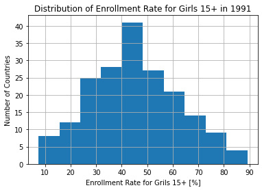

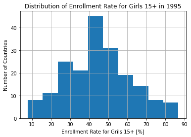

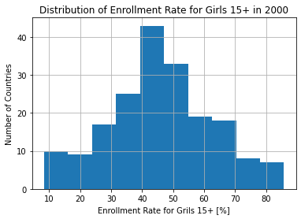

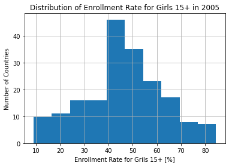

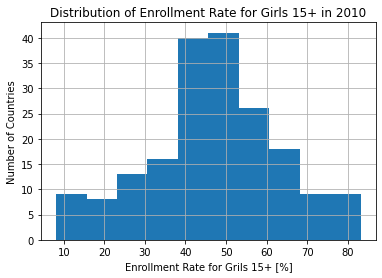

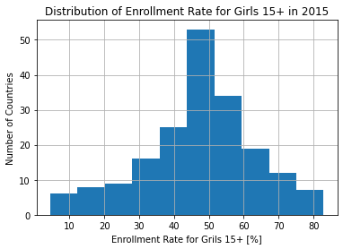

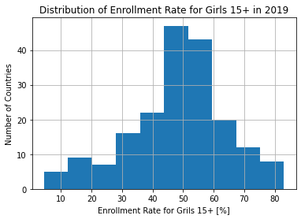

```python
for year in _5_array:
    df_erg.hist(column = year);
    plt.title('Distribution of Enrollment Rate for Girls 15+ in '+year)
    plt.xlabel('Enrollment Rate for Grils 15+ [%]')
    plt.ylabel('Number of Countries')
```

- From 1991 to 2005 the highest numbers of enrollment rate for girls 15+ were between 40 and 50.
- From 2010 to 2019 the highest numbers of enrollment rate for girls 15+ were between 40 and 60.

### Research Question 26 (Are there any trends in Continents Employment Rate for Girls 15+?)

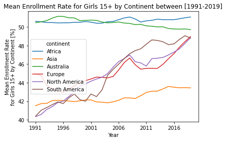

```python
df_erg.groupby('continent').mean().transpose().plot(kind='line')
plt.title('Mean Enrollment Rate for Girls 15+ by Continent between [1991-2019]')
plt.xlabel('Year')
plt.ylabel('Mean Enrollment Rate\nfor Girls 15+ by Continent [%]')
```

- Africa and Australia have realtively high enrollment rates about 50% from 1991 to 2019 which is the highest between all continents.
- Around 2008 in Europe and North America the Enrollment Rate for Grils 15+ had a relative peak.
- In Asia, from 1996 to 2019 the Enrollment Rate for Girls 15+ was the lowest between all continents.

### Research Question 27 (Are there any trends in Focusing Countries Employment Rate for Girls 15+?)

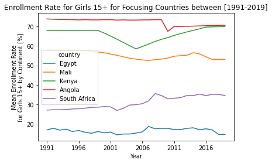

```python
df_erg.loc[focus_countries].drop('continent', axis=1).transpose().plot(kind='line')
plt.title('Enrollment Rate for Girls 15+ for Focusing Countries between [1991-2019]')
plt.xlabel('Year')
plt.ylabel('Mean Enrollment Rate\nfor Girls 15+ by Continent [%]')
```

- Egypt had the lowest Emplyment Rate for Girls 15+ between 1991 and 2019 (around 15%) and Angola had the highest rate (around 70%).
- Angola had a significantly descending line between 2008 and 2010.
- Kenya had a significant negatie peak from around 2005.
- South Africa had a significant peak around 2009.

### Research Question 28 (Which Country had the most Employment Rate for Girls 15+ over the years and in what year?)

```python
df_erg.head(1)
```

| country | continent | 1991 | 1992 | 1993 | 1994 | 1995 | 1996 | 1997 | 1998 | 1999 | ... | 2010 | 2011 | 2012 | 2013 | 2014 | 2015 | 2016 | 2017 | 2018 | 2019 |
| --- | --- | --- | --- | --- | --- | --- | --- | --- | --- | --- | --- | --- | --- | --- | --- | --- | --- | --- | --- | --- | --- |
| Afghanistan | Asia | 13.2 | 13.2 | 13.1 | 13.1 | 13.1 | 13.0 | 12.8 | 12.8 | 12.7 | ... | 12.9 | 13.2 | 13.5 | 14.3 | 15.2 | 16.1 | 17.0 | 18.0 | 18.4 | 18.8 |

1 rows × 30 columns

```python
series_temp = df_erg.drop('continent', axis=1).max(axis = 1)
```

```python
series_temp.head()
```

```
country
Afghanistan             18.8
Angola                  73.9
Albania                 51.2
United Arab Emirates    49.3
Argentina               45.9
dtype: float64
```

```python
# quering countries with the maximum values
series_temp [series_temp == series_temp.max()]
```

```
country
Burundi    89.2
dtype: float64
```

```python
series_temp = df_erg.drop('continent', axis=1).max(axis = 0)
```

```python
series_temp.head()
```

```
1991    89.2
1992    88.7
1993    88.0
1994    87.4
1995    86.8
dtype: float64
```

```python
# quering years with the maximum values
series_temp[series_temp == series_temp.max()]
```

```
1991    89.2
dtype: float64
```

```python
# cheking our result
df_erg['1991']['Burundi']
```

```
89.2
```

- Burundi had the highest Employment Rate for Girls 15+ in the world among all countries with 89.2% in 1991

### Research Question 29 (Which Country had the least Employment Rate for Girls 15+ over the years and in what year?)

```python
# repeating the previous steps but quering rows and columns that hold the minimum values
series_temp = df_erg.drop('continent', axis=1).min(axis = 1)
```

```python
series_temp.head()
```

```
country
Afghanistan             12.7
Angola                  67.5
Albania                 36.5
United Arab Emirates    28.2
Argentina               37.4
dtype: float64
```

```python
series_temp[series_temp == series_temp.min()]
```

```
country
Yemen    4.49
dtype: float64
```

```python
series_temp = df_erg.drop('continent', axis=1).min(axis = 0)
```

```python
series_temp.head()
```

```
1991    7.45
1992    7.57
1993    7.64
1994    7.71
1995    7.79
dtype: float64
```

```python
series_temp[series_temp == series_temp.min()]
```

```
2014    4.49
2016    4.49
2017    4.49
2018    4.49
dtype: float64
```

```python
# checking our result
print(df_erg['2014']['Yemen'])
print(df_erg['2016']['Yemen'])
print(df_erg['2017']['Yemen'])
print(df_erg['2018']['Yemen'])
```

```
4.49
4.49
4.49
4.49
```

- Yemen had the lowest Employment Rate for Girls 15+ in the world among all countries with 4.49% in 2014, 2016, 2017, 2018.

### Research Question 30 (Which Continent had the highest mean Emplyment Rate for Girls 15+ over the years and in what year?)

```python
# grouping the dataset by the continents' mean
df_erg.groupby('continent').mean().head()
```

| continent | 1991 | 1992 | 1993 | 1994 | 1995 | 1996 | 1997 | 1998 | 1999 | 2000 | ... | 2010 | 2011 | 2012 | 2013 | 2014 | 2015 | 2016 | 2017 | 2018 | 2019 |
| --- | --- | --- | --- | --- | --- | --- | --- | --- | --- | --- | --- | --- | --- | --- | --- | --- | --- | --- | --- | --- | --- |
| Africa | 50.615926 | 50.568889 | 50.487407 | 50.488333 | 50.448148 | 50.457037 | 50.465370 | 50.507963 | 50.515370 | 50.599259 | ... | 50.542593 | 50.672222 | 50.725926 | 50.853704 | 50.796296 | 50.800000 | 50.792593 | 50.896296 | 51.001852 | 51.083333 |
| Asia | 41.519000 | 41.744600 | 41.767600 | 42.064200 | 42.104600 | 42.076000 | 42.029200 | 41.968600 | 42.044400 | 42.136600 | ... | 42.599600 | 42.954800 | 43.080600 | 43.091800 | 43.325800 | 43.598600 | 43.513800 | 43.459000 | 43.471800 | 43.440200 |
| Australia | 50.472727 | 50.563636 | 50.690909 | 50.963636 | 51.154545 | 51.145455 | 51.000000 | 50.981818 | 50.690909 | 50.718182 | ... | 50.290909 | 50.127273 | 50.090909 | 50.018182 | 50.027273 | 49.845455 | 49.790909 | 49.772727 | 49.800000 | 49.718182 |
| Europe | 44.936585 | 44.756098 | 43.731707 | 43.351220 | 43.095122 | 42.956098 | 43.360976 | 43.621951 | 44.026829 | 44.219512 | ... | 45.456098 | 45.546341 | 45.553659 | 45.541463 | 45.973171 | 46.578049 | 47.129268 | 47.839024 | 48.431707 | 48.970732 |
| North America | 40.342857 | 40.576190 | 41.109524 | 41.419048 | 41.857143 | 42.019048 | 42.500000 | 43.000000 | 43.623810 | 43.871429 | ... | 46.133333 | 45.795238 | 46.595238 | 46.638095 | 46.723810 | 46.990476 | 47.295238 | 47.652381 | 48.238095 | 48.847619 |

5 rows × 29 columns

```python
series_temp = df_erg.groupby('continent').mean().max(axis=1)
```

```python
series_temp.head()
```

```
continent
Africa           51.083333
Asia             43.598600
Australia        51.154545
Europe           48.970732
North America    48.847619
dtype: float64
```

```python
series_temp[series_temp == series_temp.max()]
```

```
continent
Australia    51.154545
dtype: float64
```

```python
series_temp = df_erg.groupby('continent').mean().max(axis=0)
```

```python
series_temp.head()
```

```
1991    50.615926
1992    50.568889
1993    50.690909
1994    50.963636
1995    51.154545
dtype: float64
```

```python
series_temp[series_temp == series_temp.max()]
```

```
1995    51.154545
dtype: float64
```

```python
df_erg.groupby('continent').mean()['1995']['Australia']
```

```
51.154545454545456
```

- Australia had the highest mean Employment Rate for Girls 15+ in the world with 51.15% in 1995

### Research Question 31 (Which Continent had the lowest mean Emplyment Rate for Girls 15+ over the years and in what year?)

```python
# repeating previous steps but quering the minimum mean values
series_temp = df_erg.groupby('continent').mean().min(axis=1)
```

```python
series_temp.head()
```

```
continent
Africa           50.414259
Asia             41.519000
Australia        49.718182
Europe           42.956098
North America    40.342857
dtype: float64
```

```python
series_temp[series_temp == series_temp.min()]
```

```
continent
North America    40.342857
dtype: float64
```

```python
series_temp = df_erg.groupby('continent').mean().min(axis=0)
```

```python
series_temp.head()
```

```
1991    40.342857
1992    40.576190
1993    41.109524
1994    41.419048
1995    41.857143
dtype: float64
```

```python
series_temp[series_temp == series_temp.min()]
```

```
1991    40.342857
dtype: float64
```

```python
df_erg.groupby('continent').mean()['1991']['North America']
```

```
40.34285714285714
```

- North America had the lowest mean Employment Rate for Girls 15+ in the world with 40.34% in 1991

### Research Question 32 (At Which year had our Focusing Countries its Maximum Emplyment Rate for Girls 15+?)

```python
# reshaping the dataset
df_temp = df_erg.drop('continent', axis=1).transpose()
```

```python
df_temp.head(1)
```

| country | Afghanistan | Angola | Albania | United Arab Emirates | Argentina | Armenia | Australia | Austria | Azerbaijan | Burundi | ... | St. Vincent and the Grenadines | Venezuela | Virgin Islands (U.S.) | Vietnam | Vanuatu | Samoa | Yemen | South Africa | Zambia | Zimbabwe |
| --- | --- | --- | --- | --- | --- | --- | --- | --- | --- | --- | --- | --- | --- | --- | --- | --- | --- | --- | --- | --- | --- |
| 1991 | 13.2 | 73.9 | 50.8 | 28.2 | 43.6 | 45.9 | 47.3 | 42.2 | 66.5 | 89.2 | ... | 34.8 | 41.5 | 55.8 | 71.8 | 57.7 | 32.1 | 16.1 | 27.0 | 57.5 | 71.9 |

1 rows × 189 columns

```python
# looping over the focus country list to extract the maximum values
for country in focus_countries:
    print(country, 'had its maximum Employment Rate for Grils 15+ in {} with {}%'.format(df_temp[country][df_temp[country] == df_temp[country].max()].index[0], df_temp[country][df_temp[country] == df_temp[country].max()][0]))
```

```
Egypt had its maximum Employment Rate for Grils 15+ in 2007 with 18.6%
Mali had its maximum Employment Rate for Grils 15+ in 1991 with 57.8%
Kenya had its maximum Employment Rate for Grils 15+ in 2019 with 70.0%
Angola had its maximum Employment Rate for Grils 15+ in 1991 with 73.9%
South Africa had its maximum Employment Rate for Grils 15+ in 2008 with 35.5%
```

### Research Question 33 (At Which year had our Focusing Countries its Minimum Emplyment Rate for Girls 15+?)

```python
# repeating previous steps but quering minimum values
for country in focus_countries:
    print(country, 'had its minimum Employment Rate for Grils 15+ in {} with {}%'.format(df_temp[country][df_temp[country] == df_temp[country].min()].index[0], df_temp[country][df_temp[country] == df_temp[country].min()][0]))
```

```
Egypt had its minimum Employment Rate for Grils 15+ in 2002 with 14.3%
Mali had its minimum Employment Rate for Grils 15+ in 2007 with 52.5%
Kenya had its minimum Employment Rate for Grils 15+ in 2005 with 58.5%
Angola had its minimum Employment Rate for Grils 15+ in 2010 with 67.5%
South Africa had its minimum Employment Rate for Grils 15+ in 2002 with 26.8%
```

### Research Question 34 (Is there a relashionship between Total Fertility Rate and Child Mortality Rate?)

#### 1- Studying the relationship between the mean Total Fertility Rate and Child Mortality Rate for the whole world

```python
# studying the scatter plot between World's mean total fertility rate and child mortality rate
world_mean_tfr = df_tfr.drop('continent', axis=1).mean(axis=0)
world_mean_tfr.head()
```

```
1800    6.086832
1801    6.084010
1802    6.087030
1803    6.086089
1804    6.086386
dtype: float64
```

```python
world_mean_cmr = df_cmr.drop('continent', axis=1).mean(axis=0)
world_mean_cmr.head()
```

```
1800    424.918782
1801    424.309645
1802    423.685279
1803    423.274112
1804    422.898477
dtype: float64
```

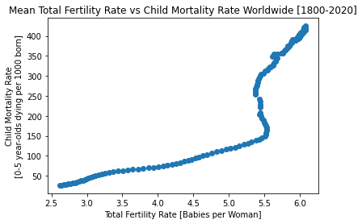

```python
plt.scatter(x=world_mean_tfr, y=world_mean_cmr)
plt.title('Mean Total Fertility Rate vs Child Mortality Rate Worldwide [1800-2020]')
plt.xlabel('Total Fertility Rate [Babies per Woman]')
plt.ylabel('Child Mortality Rate\n[0-5 year-olds dying per 1000 born]')
```

- For the mean values worldwide, untill a Total Fertility Rate of about 5.5, Total Fertility Rate and Child Mortality rate are positive correlated and then all curves tend to have a different shape

#### 2- Studying the relationship between Total Fertility Rate and Child Mortality Rate for each Cntinent

```python
# renaming the indicies of the datasets (country names) to hold an indication of what they represent
df_tfr_renamed = df_tfr.rename(index = lambda x: x + '_tfr')
df_cmr_renamed = df_cmr.rename(index = lambda x: x + '_cmr')
df_erg_renamed = df_erg.rename(index = lambda x: x+ '_erg')
```

```python
# renaming the coninents columns of the datasets to hold an indication of what they represent
df_tfr_renamed['continent'] = df_tfr_renamed['continent'].apply(lambda x: x + '_tfr')
df_cmr_renamed['continent'] = df_cmr_renamed['continent'].apply(lambda x: x + '_cmr')
df_erg_renamed['continent'] = df_erg_renamed['continent'].apply(lambda x: x + '_erg')
```

```python
df_tfr_renamed.head(1)
```

| country | continent | 1800 | 1801 | 1802 | 1803 | 1804 | 1805 | 1806 | 1807 | 1808 | ... | 2011 | 2012 | 2013 | 2014 | 2015 | 2016 | 2017 | 2018 | 2019 | 2020 |
| --- | --- | --- | --- | --- | --- | --- | --- | --- | --- | --- | --- | --- | --- | --- | --- | --- | --- | --- | --- | --- | --- |
| Aruba_tfr | North America_tfr | 5.64 | 5.64 | 5.64 | 5.64 | 5.64 | 5.64 | 5.64 | 5.64 | 5.64 | ... | 1.69 | 1.7 | 1.71 | 1.73 | 1.76 | 1.78 | 1.8 | 1.8 | 1.8 | 1.79 |

1 rows × 222 columns

```python
# creating a combined dataset for the mean values of continents over the years
cmb_temp = pd.merge(df_tfr_renamed.groupby('continent').mean().transpose(), df_cmr_renamed.groupby('continent').mean().transpose(), left_index = True, right_index = True, how = 'inner')
```

```python
cmb_temp.head()
```

| continent | Africa_tfr | Asia_tfr | Australia_tfr | Europe_tfr | North America_tfr | South America_tfr | Africa_cmr | Asia_cmr | Australia_cmr | Europe_cmr | North America_cmr | South America_cmr |
| --- | --- | --- | --- | --- | --- | --- | --- | --- | --- | --- | --- | --- |
| 1800 | 6.410175 | 6.3790 | 6.260000 | 5.360714 | 5.822963 | 6.266154 | 439.092593 | 439.673469 | 440.142857 | 383.244444 | 442.608696 | 405.5 |
| 1801 | 6.410175 | 6.3786 | 6.258462 | 5.349524 | 5.820741 | 6.266154 | 438.981481 | 439.653061 | 439.214286 | 381.488889 | 441.695652 | 405.5 |
| 1802 | 6.410000 | 6.3782 | 6.256923 | 5.366905 | 5.818148 | 6.266154 | 438.870370 | 439.530612 | 438.285714 | 379.822222 | 440.695652 | 405.5 |
| 1803 | 6.410000 | 6.3778 | 6.255385 | 5.364762 | 5.815926 | 6.266154 | 438.777778 | 439.448980 | 437.214286 | 379.022222 | 439.782609 | 405.5 |
| 1804 | 6.410175 | 6.3774 | 6.253846 | 5.368333 | 5.813704 | 6.266154 | 438.666667 | 439.326531 | 436.357143 | 378.377778 | 438.869565 | 405.5 |

```python
continent_list = ['Africa', 'Asia', 'Australia', 'Europe', 'North America', 'South America']
```

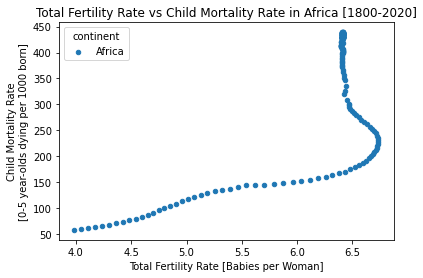

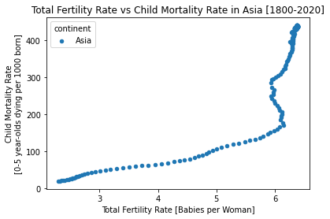

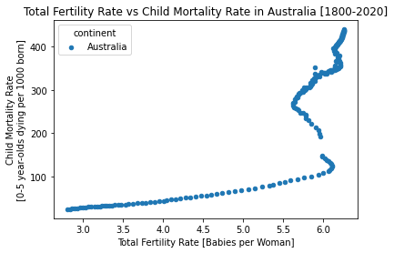

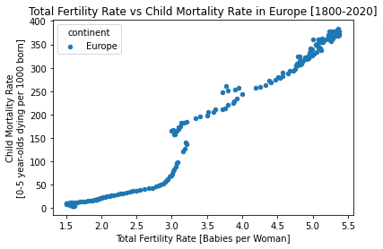

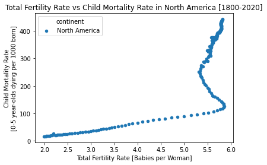

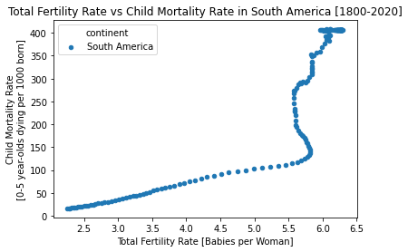

```python
# plotting the sctatter plots between total fertility rates and child mortality rates in All Continents
for con in continent_list:
    cmb_temp.plot(kind='scatter', x=[con+'_tfr'], y=[con+'_cmr'], xlabel='Total Fertility Rate [Babies per Woman]', ylabel='Child Mortality Rate\n[0-5 year-olds dying per 1000 born]', title='Total Fertility Rate vs Child Mortality Rate in '+con+' [1800-2020]', label=con)
```

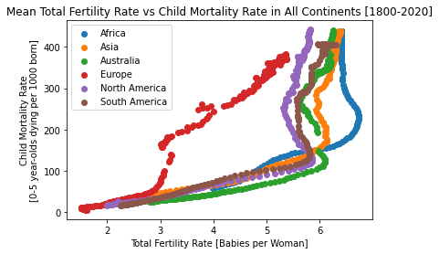

```python
# plotting a combined sctatter plot between the mean total fertility rates and child mortality rates in all Continents
continent_list = ['Africa', 'Asia', 'Australia', 'Europe', 'North America', 'South America']
for con in continent_list:
    plt.scatter(x=cmb_temp[con+'_tfr'], y=cmb_temp[con+'_cmr'], label=con)
plt.title('Mean Total Fertility Rate vs Child Mortality Rate in All Continents [1800-2020]')
plt.xlabel('Total Fertility Rate [Babies per Woman]')
plt.ylabel('Child Mortality Rate\n[0-5 year-olds dying per 1000 born]')
plt.legend()
```

- Except for Europe, the relationship between the the mean Total Fertility Rates and mean Child Mortality Rate in all continents tends to be the same.
- Except for Europe, Untill a Total Fertility Rate of about 5.5 Total Fertility Rate and Child Mortality rate are positive correlated and then all curves tend to have a different shape

#### 3- Studying the relationship between Total Fertility Rate and Child Mortality Rate for each of the Focusing Countries

```python
focus_countries
```

```
['Egypt', 'Mali', 'Kenya', 'Angola', 'South Africa']
```

```python
# merging the two datasets
cmb_temp = pd.merge(df_tfr_renamed.drop('continent', axis=1).transpose(), df_cmr_renamed.drop('continent', axis=1).transpose(), left_index = True, right_index = True, how = 'inner')
```

```python
cmb_temp.head()
```

| country | Aruba_tfr | Afghanistan_tfr | Angola_tfr | Albania_tfr | Netherlands Antilles_tfr | United Arab Emirates_tfr | Argentina_tfr | Armenia_tfr | Antigua and Barbuda_tfr | Australia_tfr | ... | Uzbekistan_cmr | St. Vincent and the Grenadines_cmr | Venezuela_cmr | Vietnam_cmr | Vanuatu_cmr | Samoa_cmr | Yemen_cmr | South Africa_cmr | Zambia_cmr | Zimbabwe_cmr |
| --- | --- | --- | --- | --- | --- | --- | --- | --- | --- | --- | --- | --- | --- | --- | --- | --- | --- | --- | --- | --- | --- |
| 1800 | 5.64 | 7.0 | 6.93 | 4.6 | 5.8 | 6.94 | 6.8 | 7.80 | 5.00 | 6.50 | ... | 381.0 | 463.0 | 415.0 | 417.0 | 426.0 | 471.0 | 540.0 | 398.0 | 410.0 | 396.0 |
| 1801 | 5.64 | 7.0 | 6.93 | 4.6 | 5.8 | 6.94 | 6.8 | 7.80 | 5.00 | 6.48 | ... | 381.0 | 461.0 | 415.0 | 417.0 | 424.0 | 468.0 | 540.0 | 398.0 | 410.0 | 396.0 |
| 1802 | 5.64 | 7.0 | 6.93 | 4.6 | 5.8 | 6.94 | 6.8 | 7.81 | 4.99 | 6.46 | ... | 381.0 | 458.0 | 415.0 | 417.0 | 421.0 | 465.0 | 540.0 | 398.0 | 410.0 | 396.0 |
| 1803 | 5.64 | 7.0 | 6.93 | 4.6 | 5.8 | 6.94 | 6.8 | 7.81 | 4.99 | 6.44 | ... | 381.0 | 456.0 | 415.0 | 417.0 | 419.0 | 461.0 | 540.0 | 398.0 | 410.0 | 396.0 |
| 1804 | 5.64 | 7.0 | 6.93 | 4.6 | 5.8 | 6.94 | 6.8 | 7.81 | 4.99 | 6.42 | ... | 381.0 | 453.0 | 415.0 | 417.0 | 417.0 | 458.0 | 540.0 | 398.0 | 410.0 | 396.0 |

5 rows × 399 columns

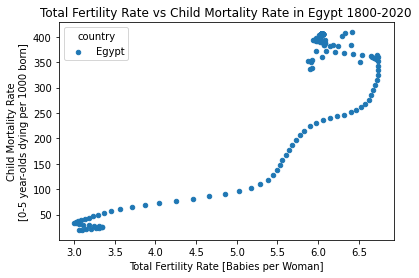

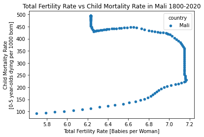

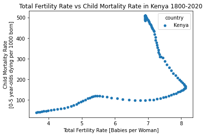

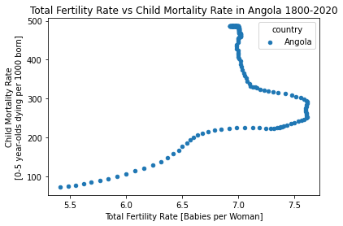

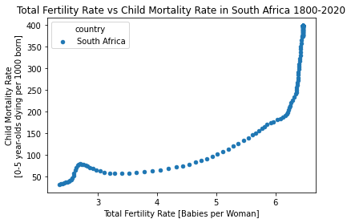

```python
# plotting the sctatter plots between total fertility rates and child mortality rates in All of our focusing Countries
for country in focus_countries:
    cmb_temp.plot(kind='scatter', x=[country+'_tfr'], y=[country+'_cmr'], xlabel='Total Fertility Rate [Babies per Woman]', ylabel='Child Mortality Rate\n[0-5 year-olds dying per 1000 born]', title='Total Fertility Rate vs Child Mortality Rate in '+country+' 1800-2020', label=country)
```

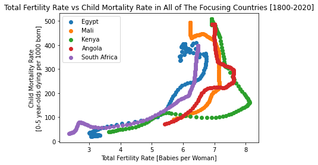

```python
# plotting a combined sctatter plot between total fertility rates and child mortality rates
for country in focus_countries:
    plt.scatter(x=cmb_temp[country+'_tfr'], y=cmb_temp[country+'_cmr'], label=country)
plt.title('Total Fertility Rate vs Child Mortality Rate in All of The Focusing Countries [1800-2020]')
plt.xlabel('Total Fertility Rate [Babies per Woman]')
plt.ylabel('Child Mortality Rate\n[0-5 year-olds dying per 1000 born]')
plt.legend()
```

### Research Question 35 (Is there a relashionship between the mean Enrollment Rate for Girls 15+ and Child Mortality Rate?)

#### 1- Studying the relationship between the mean Enrollment Rate for Girls 15+ and Child Mortality Rate for the whole world

```python
# studying the scatter plot between World's mea Enrollment rate for Girls 15+ and child mortality rate
world_mean_erg = df_erg.drop('continent', axis=1).mean(axis=0)
world_mean_erg.head()
```

```
1991    45.178360
1992    45.256878
1993    45.102646
1994    45.169206
1995    45.191164
dtype: float64
```

```python
# matching indicied (years)
world_mean_cmr = df_cmr.drop('continent', axis=1).mean(axis=0)[world_mean_erg.index]
world_mean_cmr.head()
```

```
1991    69.750305
1992    68.417411
1993    67.155025
1994    66.290761
1995    64.671066
dtype: float64
```

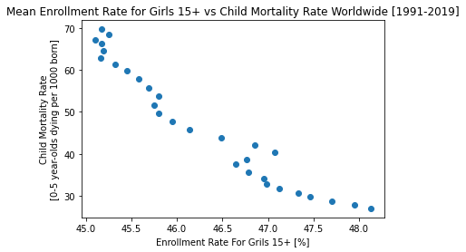

```python
plt.scatter(x=world_mean_erg, y=world_mean_cmr)
plt.title('Mean Enrollment Rate for Girls 15+ vs Child Mortality Rate Worldwide [1991-2019]')
plt.xlabel('Enrollment Rate For Grils 15+ [%]')
plt.ylabel('Child Mortality Rate\n[0-5 year-olds dying per 1000 born]')
```

- Mean Enrollment Rate for Girls 15+ and Child Mortality Rate seems to be negative correlated

#### 2- Studying the relationship between the mean Enrollment Rate for Girls 15+ and Child Mortality Rate for each Continent

```python
df_erg_renamed.head(1)
```

| country | continent | 1991 | 1992 | 1993 | 1994 | 1995 | 1996 | 1997 | 1998 | 1999 | ... | 2010 | 2011 | 2012 | 2013 | 2014 | 2015 | 2016 | 2017 | 2018 | 2019 |
| --- | --- | --- | --- | --- | --- | --- | --- | --- | --- | --- | --- | --- | --- | --- | --- | --- | --- | --- | --- | --- | --- |
| Afghanistan_erg | Asia_erg | 13.2 | 13.2 | 13.1 | 13.1 | 13.1 | 13.0 | 12.8 | 12.8 | 12.7 | ... | 12.9 | 13.2 | 13.5 | 14.3 | 15.2 | 16.1 | 17.0 | 18.0 | 18.4 | 18.8 |

1 rows × 30 columns

```python
df_cmr_renamed.head(1)
```

| country | continent | 1800 | 1801 | 1802 | 1803 | 1804 | 1805 | 1806 | 1807 | 1808 | ... | 2011 | 2012 | 2013 | 2014 | 2015 | 2016 | 2017 | 2018 | 2019 | 2020 |
| --- | --- | --- | --- | --- | --- | --- | --- | --- | --- | --- | --- | --- | --- | --- | --- | --- | --- | --- | --- | --- | --- |
| Afghanistan_cmr | Asia_cmr | 469.0 | 469.0 | 469.0 | 469.0 | 469.0 | 469.0 | 470.0 | 470.0 | 470.0 | ... | 84.1 | 80.5 | 77.0 | 73.5 | 70.4 | 67.5 | 64.7 | 62.3 | 60.1 | 58.1 |

1 rows × 222 columns

```python
# creating a combined dataset for the mean values of continents over the years
cmb_temp = pd.merge(df_erg_renamed.groupby('continent').mean().transpose(), df_cmr_renamed.groupby('continent').mean().transpose(), left_index = True, right_index = True, how = 'inner')
```

```python
cmb_temp.head()
```

| continent | Africa_erg | Asia_erg | Australia_erg | Europe_erg | North America_erg | South America_erg | Africa_cmr | Asia_cmr | Australia_cmr | Europe_cmr | North America_cmr | South America_cmr |
| --- | --- | --- | --- | --- | --- | --- | --- | --- | --- | --- | --- | --- |
| 1991 | 50.615926 | 41.5190 | 50.472727 | 44.936585 | 40.342857 | 40.391667 | 146.350000 | 64.062449 | 42.425714 | 15.036222 | 36.698261 | 48.683333 |
| 1992 | 50.568889 | 41.7446 | 50.563636 | 44.756098 | 40.576190 | 41.025000 | 144.833333 | 62.216735 | 41.253571 | 14.646222 | 35.299130 | 46.675000 |
| 1993 | 50.487407 | 41.7676 | 50.690909 | 43.731707 | 41.109524 | 41.316667 | 143.468519 | 60.464490 | 40.194286 | 14.198667 | 33.979130 | 44.691667 |
| 1994 | 50.488333 | 42.0642 | 50.963636 | 43.351220 | 41.419048 | 41.633333 | 143.511111 | 58.800000 | 39.215714 | 13.631556 | 32.719130 | 42.791667 |
| 1995 | 50.448148 | 42.1046 | 51.154545 | 43.095122 | 41.857143 | 41.925000 | 140.844444 | 57.018367 | 38.353571 | 13.068000 | 31.534348 | 40.866667 |

```python
continent_list
```

```
['Africa', 'Asia', 'Australia', 'Europe', 'North America', 'South America']
```

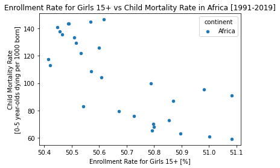

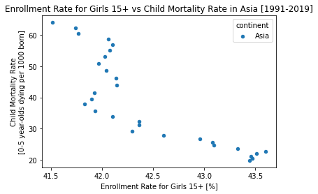

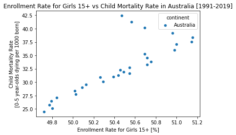

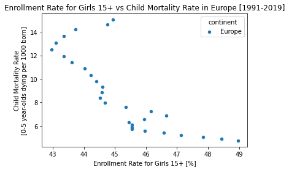

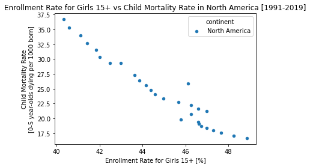

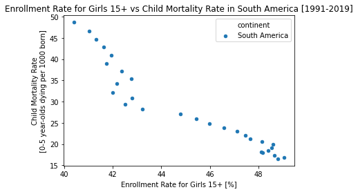

```python
# plotting the sctatter plots between mean Enrollment Rate for Girls 15+ and child mortality rates in All Continents
for con in continent_list:
    cmb_temp.plot(kind='scatter', x=[con+'_erg'], y=[con+'_cmr'], xlabel='Enrollment Rate for Girls 15+ [%]', ylabel='Child Mortality Rate\n[0-5 year-olds dying per 1000 born]', title='Enrollment Rate for Girls 15+ vs Child Mortality Rate in '+con+' [1991-2019]', label=con)
```

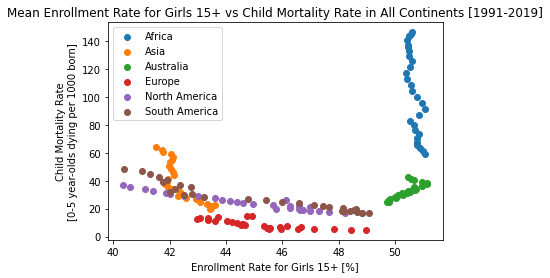

```python
# plotting a combined sctatter plot between mean Enrollment Rate for Girls 15+ and child mortality rates for all Continents
for con in continent_list:
    plt.scatter(x=cmb_temp[con+'_erg'], y=cmb_temp[con+'_cmr'], label=con)
plt.title('Mean Enrollment Rate for Girls 15+ vs Child Mortality Rate in All Continents [1991-2019]')
plt.xlabel('Enrollment Rate for Girls 15+ [%]')
plt.ylabel('Child Mortality Rate\n[0-5 year-olds dying per 1000 born]')
plt.legend()
```

- Unlike other Continents, Australia seems to have a positive correlation between mean Enrollment Rate for Girls 15+ and Child Mortality Rate

#### 3- Studying the relationship between Enrollment Rate for Girls 15+ and Child Mortality Rate for each of the Focusing Countries

```python
focus_countries
```

```
['Egypt', 'Mali', 'Kenya', 'Angola', 'South Africa']
```

```python
cmb_temp = pd.merge(df_erg_renamed.drop('continent', axis=1).transpose(), df_cmr_renamed.drop('continent', axis=1).transpose(), left_index = True, right_index = True, how = 'inner')
```

```python
cmb_temp.head()
```

| country | Afghanistan_erg | Angola_erg | Albania_erg | United Arab Emirates_erg | Argentina_erg | Armenia_erg | Australia_erg | Austria_erg | Azerbaijan_erg | Burundi_erg | ... | Uzbekistan_cmr | St. Vincent and the Grenadines_cmr | Venezuela_cmr | Vietnam_cmr | Vanuatu_cmr | Samoa_cmr | Yemen_cmr | South Africa_cmr | Zambia_cmr | Zimbabwe_cmr |
| --- | --- | --- | --- | --- | --- | --- | --- | --- | --- | --- | --- | --- | --- | --- | --- | --- | --- | --- | --- | --- | --- |
| 1991 | 13.2 | 73.9 | 50.8 | 28.2 | 43.6 | 45.9 | 47.3 | 42.2 | 66.5 | 89.2 | ... | 72.2 | 23.1 | 28.5 | 48.9 | 34.2 | 29.1 | 122.0 | 57.8 | 187.0 | 84.0 |
| 1992 | 13.2 | 73.7 | 51.2 | 28.9 | 43.8 | 45.7 | 46.8 | 43.3 | 68.1 | 88.7 | ... | 72.2 | 22.7 | 27.8 | 46.4 | 32.9 | 28.2 | 119.0 | 57.1 | 187.0 | 88.2 |
| 1993 | 13.1 | 73.6 | 49.5 | 29.8 | 41.8 | 43.1 | 46.6 | 43.5 | 68.8 | 88.0 | ... | 71.9 | 22.4 | 27.2 | 43.9 | 31.9 | 27.2 | 116.0 | 57.2 | 186.0 | 92.9 |
| 1994 | 13.1 | 73.6 | 48.3 | 30.2 | 41.6 | 42.4 | 47.7 | 46.0 | 69.7 | 87.4 | ... | 71.4 | 22.3 | 26.7 | 41.4 | 31.1 | 26.2 | 114.0 | 58.2 | 184.0 | 97.2 |
| 1995 | 13.1 | 73.5 | 46.5 | 30.6 | 37.4 | 41.4 | 49.3 | 46.4 | 69.8 | 86.8 | ... | 70.6 | 22.3 | 26.2 | 39.1 | 30.5 | 25.3 | 112.0 | 60.2 | 181.0 | 101.0 |

5 rows × 386 columns

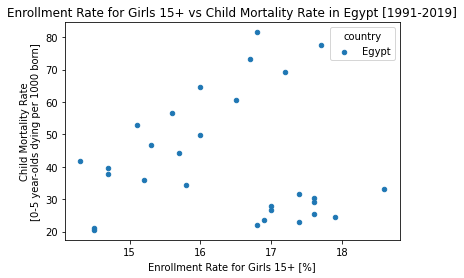

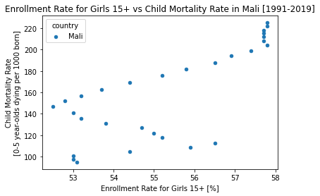

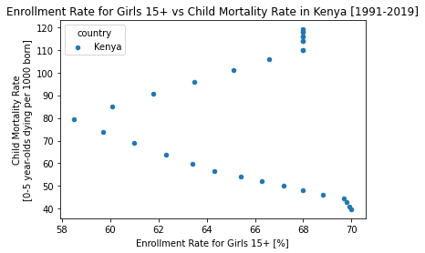

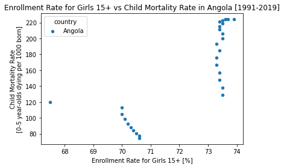

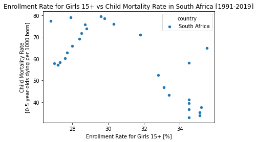

```python
# plotting the sctatter plots between Enrollment Rate for Girls 15+ and child mortality rates in All of our focusing Countries
for country in focus_countries:
    cmb_temp.plot(kind='scatter', x=[country+'_erg'], y=[country+'_cmr'], xlabel='Enrollment Rate for Girls 15+ [%]', ylabel='Child Mortality Rate\n[0-5 year-olds dying per 1000 born]', title='Enrollment Rate for Girls 15+ vs Child Mortality Rate in '+country+' [1991-2019]', label=country)
```

- Enrollment Rate for Girls 15+ and Child Mortality Rate are not correlated for any of our focusing countries

### Research Question 36 (Is there a relashionship between the mean Enrollment Rate for Girls 15+ and Total Fertility Rate?)

#### 1- Studying the relationship between the mean Enrollment Rate for Girls 15+ and Total Fertility Rate for the whole world

```python
# studying the scatter plot between World's mea Enrollment rate for Girls 15+ and total fertility rate
world_mean_erg = df_erg.drop('continent', axis=1).mean(axis=0)
world_mean_erg.head()
```

```
1991    45.178360
1992    45.256878
1993    45.102646
1994    45.169206
1995    45.191164
dtype: float64
```

```python
# matching indicied (years) between [1991 - 2019]
world_mean_tfr = df_tfr.drop('continent', axis=1).mean(axis=0)[world_mean_erg.index]
world_mean_tfr.head()
```

```
1991    3.866436
1992    3.793267
1993    3.718218
1994    3.646386
1995    3.573267
dtype: float64
```

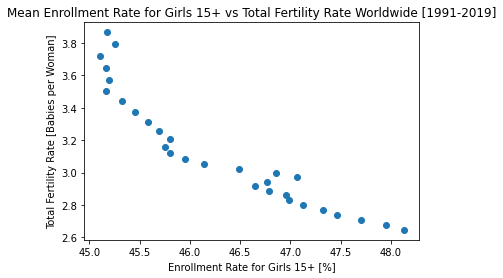

```python
plt.scatter(x=world_mean_erg, y=world_mean_tfr)
plt.title('Mean Enrollment Rate for Girls 15+ vs Total Fertility Rate Worldwide [1991-2019]')
plt.xlabel('Enrollment Rate for Girls 15+ [%]')
plt.ylabel('Total Fertility Rate [Babies per Woman]')
```

- Mean Enrollment Rate for Girls 15+ and Total Fertility Rate seems to be negative correlated.

#### 2- Studying the relationship between the mean Enrollment Rate for Girls 15+ and Total Fertility Rate for each Continent

```python
df_erg_renamed.head(1)
```

| country | continent | 1991 | 1992 | 1993 | 1994 | 1995 | 1996 | 1997 | 1998 | 1999 | ... | 2010 | 2011 | 2012 | 2013 | 2014 | 2015 | 2016 | 2017 | 2018 | 2019 |
| --- | --- | --- | --- | --- | --- | --- | --- | --- | --- | --- | --- | --- | --- | --- | --- | --- | --- | --- | --- | --- | --- |
| Afghanistan_erg | Asia_erg | 13.2 | 13.2 | 13.1 | 13.1 | 13.1 | 13.0 | 12.8 | 12.8 | 12.7 | ... | 12.9 | 13.2 | 13.5 | 14.3 | 15.2 | 16.1 | 17.0 | 18.0 | 18.4 | 18.8 |

1 rows × 30 columns

```python
df_tfr_renamed.head(1)
```

| country | continent | 1800 | 1801 | 1802 | 1803 | 1804 | 1805 | 1806 | 1807 | 1808 | ... | 2011 | 2012 | 2013 | 2014 | 2015 | 2016 | 2017 | 2018 | 2019 | 2020 |
| --- | --- | --- | --- | --- | --- | --- | --- | --- | --- | --- | --- | --- | --- | --- | --- | --- | --- | --- | --- | --- | --- |
| Aruba_tfr | North America_tfr | 5.64 | 5.64 | 5.64 | 5.64 | 5.64 | 5.64 | 5.64 | 5.64 | 5.64 | ... | 1.69 | 1.7 | 1.71 | 1.73 | 1.76 | 1.78 | 1.8 | 1.8 | 1.8 | 1.79 |

1 rows × 222 columns

```python
# creating a combined dataset for the mean values of continents over the years
cmb_temp = pd.merge(df_erg_renamed.groupby('continent').mean().transpose(), df_tfr_renamed.groupby('continent').mean().transpose(), left_index = True, right_index = True, how = 'inner')
```

```python
cmb_temp.head()
```

| continent | Africa_erg | Asia_erg | Australia_erg | Europe_erg | North America_erg | South America_erg | Africa_tfr | Asia_tfr | Australia_tfr | Europe_tfr | North America_tfr | South America_tfr |
| --- | --- | --- | --- | --- | --- | --- | --- | --- | --- | --- | --- | --- |
| 1991 | 50.615926 | 41.5190 | 50.472727 | 44.936585 | 40.342857 | 40.391667 | 5.789298 | 3.9480 | 3.950000 | 1.813095 | 3.051111 | 3.365385 |
| 1992 | 50.568889 | 41.7446 | 50.563636 | 44.756098 | 40.576190 | 41.025000 | 5.704211 | 3.8366 | 3.898462 | 1.772857 | 3.000000 | 3.317692 |
| 1993 | 50.487407 | 41.7676 | 50.690909 | 43.731707 | 41.109524 | 41.316667 | 5.621404 | 3.7254 | 3.840769 | 1.727857 | 2.940741 | 3.268462 |
| 1994 | 50.488333 | 42.0642 | 50.963636 | 43.351220 | 41.419048 | 41.633333 | 5.541579 | 3.6146 | 3.786154 | 1.692143 | 2.881481 | 3.221538 |
| 1995 | 50.448148 | 42.1046 | 51.154545 | 43.095122 | 41.857143 | 41.925000 | 5.464737 | 3.5014 | 3.732308 | 1.650952 | 2.821852 | 3.168462 |

```python
continent_list
```

```
['Africa', 'Asia', 'Australia', 'Europe', 'North America', 'South America']
```

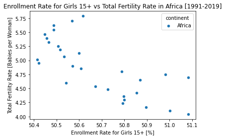

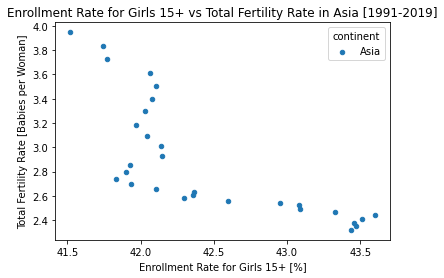

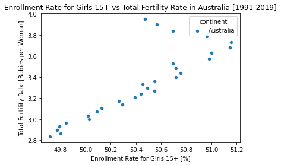

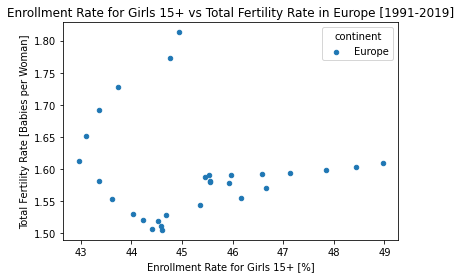

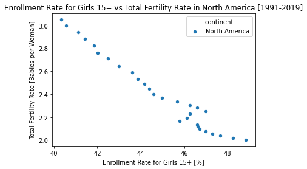

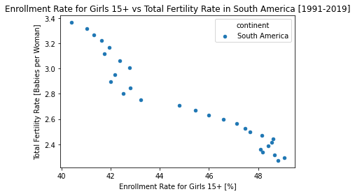

```python
# plotting the sctatter plots between mean Enrollment Rate for Girls 15+ and child mortality rates in All Continents
for con in continent_list:
    cmb_temp.plot(kind='scatter', x=[con+'_erg'], y=[con+'_tfr'], xlabel='Enrollment Rate for Girls 15+ [%]', ylabel='Total Fertility Rate [Babies per Woman]', title='Enrollment Rate for Girls 15+ vs Total Fertility Rate in '+con+' [1991-2019]', label=con)
```

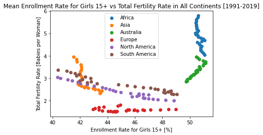

```python
# plotting a combined sctatter plot between mean Enrollment Rate for Girls 15+ and Total Fertility Rate for all Continents
for con in continent_list:
    plt.scatter(x=cmb_temp[con+'_erg'], y=cmb_temp[con+'_tfr'], label=con)
plt.title('Mean Enrollment Rate for Girls 15+ vs Total Fertility Rate in All Continents [1991-2019]')
plt.xlabel('Enrollment Rate for Girls 15+ [%]')
plt.ylabel('Total Fertility Rate [Babies per Woman]')
plt.legend()
```

- In Africa, North America and South America, Mean Enrollment Rate for Girls 15+ and Total Fertility Rate are negative correlated.
- In Europe, there is no correlation between Mean Enrollment Rate for Girls 15+ and Total Fertility Rate.
- In Australia, Mean Enrollment Rate for Girls 15+ and Total Fertility Rate are positive correlated

#### 3- Studying the relationship between Enrollment Rate for Girls 15+ and Total Fertility Rate for each of the Focusing Countries

```python
focus_countries
```

```
['Egypt', 'Mali', 'Kenya', 'Angola', 'South Africa']
```

```python
cmb_temp = pd.merge(df_erg_renamed.drop('continent', axis=1).transpose(), df_tfr_renamed.drop('continent', axis=1).transpose(), left_index = True, right_index = True, how = 'inner')
```

```python
cmb_temp.head()
```

| country | Afghanistan_erg | Angola_erg | Albania_erg | United Arab Emirates_erg | Argentina_erg | Armenia_erg | Australia_erg | Austria_erg | Azerbaijan_erg | Burundi_erg | ... | St. Vincent and the Grenadines_tfr | Venezuela_tfr | Virgin Islands (U.S.)_tfr | Vietnam_tfr | Vanuatu_tfr | Samoa_tfr | Yemen_tfr | South Africa_tfr | Zambia_tfr | Zimbabwe_tfr |
| --- | --- | --- | --- | --- | --- | --- | --- | --- | --- | --- | --- | --- | --- | --- | --- | --- | --- | --- | --- | --- | --- |
| 1991 | 13.2 | 73.9 | 50.8 | 28.2 | 43.6 | 45.9 | 47.3 | 42.2 | 66.5 | 89.2 | ... | 2.91 | 3.37 | 2.90 | 3.42 | 4.89 | 5.03 | 8.46 | 3.53 | 6.38 | 5.00 |
| 1992 | 13.2 | 73.7 | 51.2 | 28.9 | 43.8 | 45.7 | 46.8 | 43.3 | 68.1 | 88.7 | ... | 2.86 | 3.29 | 2.81 | 3.26 | 4.85 | 4.96 | 8.27 | 3.41 | 6.33 | 4.84 |
| 1993 | 13.1 | 73.6 | 49.5 | 29.8 | 41.8 | 43.1 | 46.6 | 43.5 | 68.8 | 88.0 | ... | 2.81 | 3.22 | 2.71 | 3.09 | 4.81 | 4.88 | 8.05 | 3.29 | 6.28 | 4.69 |
| 1994 | 13.1 | 73.6 | 48.3 | 30.2 | 41.6 | 42.4 | 47.7 | 46.0 | 69.7 | 87.4 | ... | 2.76 | 3.15 | 2.60 | 2.90 | 4.78 | 4.82 | 7.80 | 3.20 | 6.23 | 4.56 |
| 1995 | 13.1 | 73.5 | 46.5 | 30.6 | 37.4 | 41.4 | 49.3 | 46.4 | 69.8 | 86.8 | ... | 2.70 | 3.08 | 2.48 | 2.71 | 4.73 | 4.75 | 7.53 | 3.11 | 6.19 | 4.43 |

5 rows × 391 columns

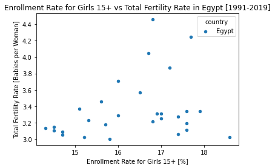

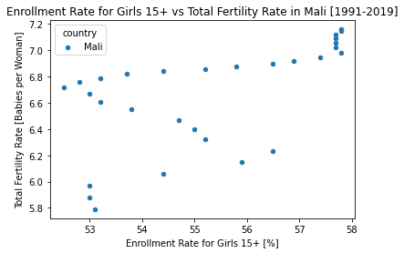

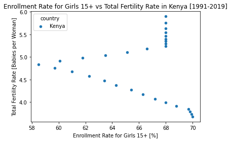

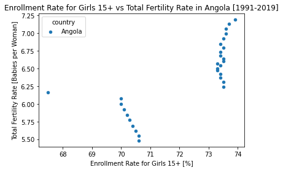

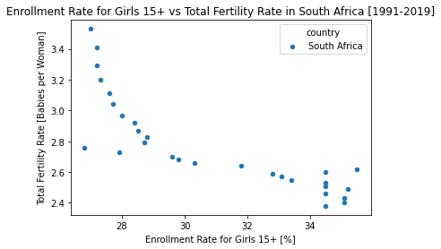

```python
# plotting the sctatter plots between Enrollment Rate for Girls 15+ and total fertility rates in All of our focusing Countries
for country in focus_countries:
    cmb_temp.plot(kind='scatter', x=[country+'_erg'], y=[country+'_tfr'], xlabel='Enrollment Rate for Girls 15+ [%]', ylabel='Total Fertility Rate [Babies per Woman]', title='Enrollment Rate for Girls 15+ vs Total Fertility Rate in '+country+' [1991-2019]', label=country)
```

## Conclusions

### Important Notes:

- This report is based only on descriptive statistics and all conclusions are tetative.
- This report explores and analyses only three indicators among other indicators that could affect the results.
- Stating the correlation between two variables doesn't necessarily mean that one of the is a cuase for the other because as noted before there are other indicators that affects each indicator.

### More data that could improve the analyses:

- We only had the data between 1991 and 2019 for Enrollment Rate for Girls 15+, an expansion to this data could improve our analyses to track the changes that happened to this indicator over the years and to explore the relashionship between it and the two other indicators in this report (Total Fertility Rate and Child Mortality Rate).

### Additional Research that could be done:

- The relshionship between Girls Primary School Complition and the three indicators in the report.
- The relashionship between the Economy and the three indicators in the report.
- The relashionship between the Environment and the three indicators in the report.

### Conclusions:

#### 1- Exploring Total Fertility Rate between 1800 and 2020 (Research Questions 1:9):

- Unitll 1950 the highest numbers of Total Fertility Rates were between 5.5 and 7.
- In 1975 the curve has flattened alittle bit and the highest numbers of Total Fertility Rates were between 5.5 and 7 but the numbers between 1 and 3 has raised significantly.
- In 2000 the curve has been skewed to the right with highest numbers of Total Fertility Rates between 1 and 3.
- In 2020 the curve has been more skewed to the right with highest numbers of Total Fertility Rates between 1 and 3.
- Africa had the highest mean Total Fertility Rates over the years.
- Europe had the lowest mean Total Fertility Rates over the years
- Except for Europe, the curves were quite steady untill the 1950s.
- Except for Europe, the mean Total Fertility Rate was significantly ascending between 1950 and 1960 and then the curves started descending fastly unitl 2020, afirca had the same approach with some delay.
- Europe had a descending curve from the beginning (1800) until 2000, but the descendece between 1900 and 2000 was alot faster than the descendence between 1800 and 1900.
- Europe is the only Continent that had an ascending curve (inceasing in mean total fertility rates) between 2000 and 2020.
- In our focusing countries, except for South Africa, the other four countries had the same increasing in total fertility rates betweeb 1950 and 1960 and then the curves started descending fastly untill 2020.
- Egypt had an significant increase and then decrease in total fertility rates in the 1920s and 1930s.
- Egypt is the only country from the five countries that had an increases in total fertility rates between 2000 and 2010 and the the curve started to descending again.
- Yemen had the most total fertility rate over the years with 8.87 in 1985.
- Macao, China had the lowest total fertility rate over the years with 0.83 in 2003 and 2004.
- The year with maximum mean Total Fertility Rate in Africa is 1968 with a rate of 6.73.
- The Year with maximum mean Total Fertility Rate in Asia is 1827 with a rate of 6.39.
- The year with maximum mean Total Fertility Rate in Australia is 1800 with a rate of 6.26.
- The year with maximum mean Total Fertility Rate in Europe is 1821 with a rate of 5.38.
- The year with maximum mean Total Fertility Rate in North America is 1959 with a rate of 5.86.
- The year with maximum mean Total Fertility Rate in South America is 1860 with a rate of 6.30.
- The year with minimum mean Total Fertility Rate in Africa is 2020 with a rate of 3.98.
- The year with minimum mean Total Fertility Rate in Asia is 2020 with a rate of 2.29.
- The year with minimum mean Total Fertility Rate in Australia is 2020 with a rate of 2.80.
- The year with minimum mean Total Fertility Rate in Europe is 2002 with a rate of 1.50.
- The year with minimum mean Total Fertility Rate in North America is 2020 with a rate of 1.99.
- The year with minimum mean Total Fertility Rate in South America is 2020 with a rate of 2.25.
- Years with maximum Total Fertility Rate in Egypt are:  
  Year TFR  
  1956 6.74  
  1957 6.74  
  1958 6.74
- Years with maximum Total Fertility Rate in Mali are:  
  Year TFR  
  1990 7.17
- Years with maximum Total Fertility Rate in Kenya are:  
  Year TFR  
  1966 8.13  
  1967 8.13
- Years with maximum Total Fertility Rate in Angola are:  
  Year TFR  
  1965 7.62  
  1966 7.62  
  1975 7.62
- The year with minimum Total Fertility Rate in Egypt is 2006 with a rate of 3.0.
- The year with minimum Total Fertility Rate in Mali is 2020 with a rate of 5.7.
- The year with minimum Total Fertility Rate in Kenya is 2020 with a rate of 3.63.
- The year with minimum Total Fertility Rate in Angola is 2020 with a rate of 5.41.
- The year with minimum Total Fertility Rate in South Africa is 2020 with a rate of 2.35.

#### 2- Exploring Child Mortality Rate between 1800 and 2020 (Research Questions 10:24):

- In 1800 and 1825 the highest numbers of child mortality rates were between 400 and 450.
- From 1850 to 1925 the highest number of child mortality rate was about 400.
- In 1950 the curve has flattened, the hightes number of child mortality rate was about 150 and numbers above 350 were the lowest.
- In 1975 the curve has been skewed to the right and numbers between 0 and 50 were the highest.
- In 2000 the curver has been skewed to the right and numbers between 0 and 25 were the highest.
- In 2020 the curver has been skewed to the right and numbers between 0 and 10 were the highest.
- Europe had the lowest child mortality rate between 1800 and 2020 and Africa had the highest.
- Africa and Asia had almost the same child mortality rates between 1800 and 1900 but starting from 1900 the descendency in child mortality rate in Asia was much faster than it is in Africa.
- Around 2000 the child mortality rate in Angola, Kenya and South Africa has been raised significantly and then started descending agian.
- The countries that has the highest child mortality rate between 1800 and 2020 were Philippines and Palau in 1902.
- The coutry that had the lowest child mortality rate between 1800 and 2020 is Finland in 2020.
- The year with maximum mean Child Mortality Rate in Africa is 1800 with a rate of 439.09.
- The year with maximum mean Child Mortality Rate in Asia is 1800 with a rate of 439.67.
- The year with maximum mean Child Mortality Rate in Australia is 1800 with a rate of 440.14.
- The year with maximum mean Child Mortality Rate in Europe is 1800 with a rate of 383.24.
- The year with maximum mean Child Mortality Rate in North America is 1800 with a rate of 442.60.
- The year with maximum mean Child Mortality Rate in South America is 1895 with a rate of 407.83.
- The year with minimum mean Child Mortality Rate in Africa is 2020 with a rate of 57.63.
- The year with minimum mean Child Mortality Rate in Asia is 2020 with a rate of 19.15.
- The year with minimum mean Child Mortality Rate in Australia is 2020 with a rate of 23.89.
- The year with minimum mean Child Mortality Rate in Europe is 2020 with a rate of 4.61.
- The year with minimum mean Child Mortality Rate in North America is 2020 with a rate of 16.28.
- The year with minimum mean Child Mortality Rate in South America is 2020 with a rate of 16.20.
- The year with maximum Child Mortality Rate in Egypt is 1929 with a rate of 409.
- The year with minimum Child Mortality Rate in Egypt is 2020 with a rate of 19.8.
- The year with minimum Child Mortality Rate in Mali is 2020 with a rate of 92.4.
- The year with minimum Child Mortality Rate in Kenya is 2020 with a rate of 38.5.
- The year with minimum Child Mortality Rate in Angola is 2020 with a rate of 72.3.
- The year with minimum Child Mortality Rate in South Africa is 2020 with a rate of 32.1.
- Sierra Leone had lost the most number of children per 1000 child between 1800 and 2020 with a mean value about 433 child per 1000 child per year
- Norway had lost the lowest number of children per 1000 child between 1800 and 2020 with a mean value about 123 child per 1000 child per year.
- Africa had lost the most number of children per 1000 child between 1800 and 2020 with a mean value about 341 child per 1000 child per year.
- Europe had lost the lowest number of children per 1000 child between 1800 and 2020 with a mean value about 220 child per 1000 child per year.
- In our focusing coutries, Mali had lost the highest number of children per 1000 child between 1800 and 2020 with a mean value about 415 child per 1000 child per year.
- In our focusing countries, South had lost the lowest number of children per 1000 child between 1800 and 2020 with a mean value about 295 child per 1000 child per year.

#### 3- Exploring Enrollment Rate for Girls 15+ between 1991 and 2019 (Research Questions 25:33):

- From 1991 to 2005 the highest numbers of enrollment rate for girls 15+ were between 40 and 50.
- From 2010 to 2019 the highest numbers of enrollment rate for girls 15+ were between 40 and 60.
- Africa and Australia have realtively high enrollment rates about 50% from 1991 to 2019 which is the highest between all continents.
- Around 2008 in Europe and North America the Enrollment Rate for Grils 15+ had a relative peak.
- In Asia, from 1996 to 2019 the Enrollment Rate for Girls 15+ was the lowest between all continents.
- In our focusing countries, Egypt had the lowest Emplyment Rate for Girls 15+ between 1991 and 2019 (around 15%) and Angola had the highest rate (around 70%).
- Angola had a significantly descending line between 2008 and 2010.
- Kenya had a significant negatie peak from around 2005.
- South Africa had a significant peak around 2009.
- In our focusing countries, Egypt had the lowest Emplyment Rate for Girls 15+ between 1991 and 2019 (around 15%) and Angola had the highest rate (around 70%).
- Angola had a significantly descending line between 2008 and 2010.
- Kenya had a significant negatie peak from around 2005.
- South Africa had a significant peak around 2009.
- Burundi had the highest Employment Rate for Girls 15+ in the world among all countries with 89.2% in 1991
- Yemen had the lowest Employment Rate for Girls 15+ in the world among all countries with 4.49% in 2014, 2016, 2017, 2018.
- Australia had the highest mean Employment Rate for Girls 15+ in the world with 51.15% in 1995
- North America had the lowest mean Employment Rate for Girls 15+ in the world with 40.34% in 1991
- Egypt had its maximum Employment Rate for Grils 15+ in 2007 with 18.6%
- Mali had its maximum Employment Rate for Grils 15+ in 1991 with 57.8%
- Kenya had its maximum Employment Rate for Grils 15+ in 2019 with 70.0%
- Angola had its maximum Employment Rate for Grils 15+ in 1991 with 73.9%
- South Africa had its maximum Employment Rate for Grils 15+ in 2008 with 35.5%
- Egypt had its minimum Employment Rate for Grils 15+ in 2002 with 14.3%
- Mali had its minimum Employment Rate for Grils 15+ in 2007 with 52.5%
- Kenya had its minimum Employment Rate for Grils 15+ in 2005 with 58.5%
- Angola had its minimum Employment Rate for Grils 15+ in 2010 with 67.5%
- South Africa had its minimum Employment Rate for Grils 15+ in 2002 with 26.8%